# Assignment3

Ming Nie

3/29/2021

```r
setwd("D:/Github/Nie_Ming/assignment 3")
d = read.csv("kickstarter_projects_2021-03.csv")
glimpse(d)
```

```
## Rows: 125,926
## Columns: 24
## $ backers_count            <int> 4, 35, 310, 1, 36, 22, 10, 187, 5, 1, 1, 8...
## $ blurb                    <chr> "Soaps made with love, care, creativity an...
## $ converted_pledged_amount <int> 41, 2205, 8861, 100, 1026, 1495, 2591, 451...
## $ country                  <chr> "USA", "USA", "USA", "USA", "USA", "USA", ...
## $ country_displayable_name <chr> "the United States", "the United States", ...
## $ created_at               <chr> "2017-12-04", "2018-06-07", "2015-09-23", ...
## $ currency                 <chr> "USD", "USD", "USD", "USD", "USD", "USD", ...
## $ deadline                 <chr> "2018-01-04", "2018-07-11", "2015-11-15", ...
## $ goal                     <dbl> 150, 900, 8500, 50000, 800, 12000, 24000, ...
## $ id                       <int> 123246984, 1207132794, 1899686686, 1081353...
## $ is_starrable             <lgl> FALSE, FALSE, FALSE, FALSE, FALSE, FALSE, ...
## $ launched_at              <chr> "2017-12-05", "2018-06-11", "2015-10-01", ...
## $ name                     <chr> "Soaps in Texas", "Whiskey Pens", "The Pos...
## $ pledged                  <dbl> 41.00, 2205.00, 8861.00, 100.00, 1026.00, ...
## $ slug                     <chr> "soaps-in-texas", "whiskey-pens", "the-pos...
## $ source_url               <chr> "https://www.kickstarter.com/discover/cate...
## $ spotlight                <lgl> FALSE, TRUE, TRUE, FALSE, TRUE, FALSE, FAL...
## $ staff_pick               <lgl> FALSE, FALSE, FALSE, FALSE, TRUE, FALSE, F...
## $ state                    <chr> "failed", "successful", "successful", "fai...
## $ state_changed_at         <chr> "2018-01-04", "2018-07-11", "2015-11-15", ...
## $ location_town            <chr> "Edinburg", "Columbia", "Jacksonville", "D...
## $ location_state           <chr> "TX", "SC", "FL", "MI", "FL", "OR", "MN", ...
## $ top_category             <chr> "crafts", "crafts", "dance", "crafts", "cr...
## $ sub_category             <chr> "diy", "woodworking", "spaces", "diy", "ca...
```

1. Success by Category There are several ways to identify success of a project:
- State (state): Whether a campaign was successful or not.
- Pledged Amount (pledged)
- Achievement Ratio: The variable achievement_ratio is calculating the percentage of the original monetary goal reached by the actual amount pledged (that is pledged).
- Number of backers (backers_count)
- How quickly the goal was reached (difference between launched_at and state_changed_at) for those campaigns that were successful.

Use one or more of these measures to visually summarize which categories were most successful in attracting funding on kickstarter. Briefly summarize your findings.

Answer: some states have a higher chance of success, for example, NY. Others may have a high chance of failure, like FL.

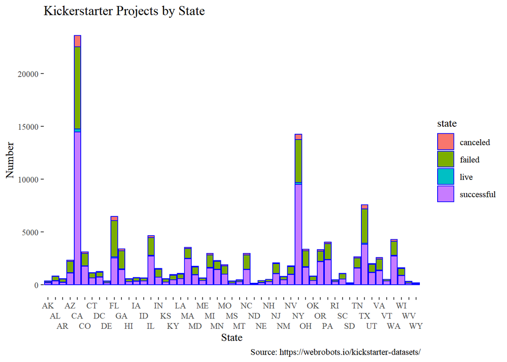

```r
ggplot(d, aes(x = location_state, fill = state), position = "fill") +
  geom_bar(color = "blue") +
  scale_x_discrete(guide = guide_axis(n.dodge=3))+
  labs(x = "State", y = "Number",
       title = "Kickerstarter Projects by State",
       caption = "Source: https://webrobots.io/kickstarter-datasets/") +
theme_tufte()
```

BONUS ONLY: b) Success by Location Now, use the location information to calculate the total number of successful projects by state (if you are ambitious, normalize by population). Also, identify the Top 50 “innovative” cities in the U.S. (by whatever measure you find plausible). Provide a leaflet map showing the most innovative states and cities in the U.S. on a single map based on these information.

```r
d_state <- d  %>% filter(state == "successful")%>% group_by(location_state) %>% dplyr::summarise(count = n())
d_city <-d %>%  group_by(location_town) %>% dplyr::summarise(avg_backers = mean(backers_count, na.rm=TRUE))%>% top_n(50)
library(leaflet)
register_google(key = "AIzaSyAZR98v6UwpaGNZJi3i8iwotGG9vKl5VME")
```

```r
d_location <- full_join(d_state , d_city, by = c ("location_state"= "location_town"))
d_location <- rename(d_location, c("location_state" = "location" ))
```

```r
library(leaflet)
d_geo <- geocode(d_location$location)
```

```
## "AR" not uniquely geocoded, using "1020 s rockford ave d, tulsa, ok 74120, usa"
```

```
## "DE" not uniquely geocoded, using "united states"
```

```
## "ME" not uniquely geocoded, using "55 s main st ste 200, naperville, il 60540, usa"
```

```
## "OH" not uniquely geocoded, using "ohio, usa"
```

```
## "Brighton" not uniquely geocoded, using "2203 s promenade blvd, rogers, ar 72758, usa"
```

```
## "Grimes" not uniquely geocoded, using "grimes, ia, usa"
```

```r
d_location = data.frame(d_location,d_geo)
m <- leaflet(d_location) %>%
  addTiles() %>%
  addCircles(lng = ~lon, lat = ~lat)
content <- paste("count",d_location$count,"<br/>",
                 "Average backer number",d_location$avg_backers,"<br/>")
(mpop2 <- m %>% addCircles( popup = content))
```

```
## Assuming "lon" and "lat" are longitude and latitude, respectively
```

[interactive chart not shown]

2. Writing your success story Each project contains a blurb – a short description of the project. While not the full description of the project, the short headline is arguably important for inducing interest in the project (and ultimately popularity and success). Let’s analyze the text.
1. Cleaning the Text and Word Cloud To reduce the time for analysis, select the 1000 most successful projects and a sample of 1000 unsuccessful projects.

since I have so many projects with 0 backers, I take 1000 samples

```r
d_top <- d %>% top_n(1000,d$backers_count)
d_bot <- d %>%  top_n(-100,backers_count) %>% sample_n(1000)
d_tb <- full_join(d_top , d_bot, by = c ("blurb"= "blurb"))
```

Use the cleaning functions introduced in lecture (or write your own in addition) to remove unnecessary words (stop words), syntax, punctuation, numbers, white space etc. Note, that many projects use their own unique brand names in upper cases, so try to remove these fully capitalized words as well (since we are aiming to identify common words across descriptions). Create a document-term-matrix.

```r
str_tb <-  as.matrix(d_tb$blurb  %>% tolower() %>% removeNumbers()%>% removeWords( stopwords("en"))%>% stripWhitespace()%>% removePunctuation())

str_top <-  as.matrix(d_top$blurb  %>% tolower() %>% removeNumbers()%>% removeWords( stopwords("en"))%>% stripWhitespace()%>% removePunctuation())

str_bot <-  as.matrix(d_bot$blurb  %>% tolower() %>% removeNumbers()%>% removeWords( stopwords("en"))%>% stripWhitespace()%>% removePunctuation())
```

```r
stemCompletion2 <- function(x, dictionary) {
   x <- unlist(strsplit(as.character(x), " "))
   x <- x[x != ""]
   x <- stemCompletion(x, dictionary=dictionary)
   x <- paste(x, sep="", collapse=" ")
   PlainTextDocument(stripWhitespace(x))
}
```

```r
dtm_tb <- str_tb %>% lapply(stemCompletion2, dictionary=str_tb) %>% as.VCorpus() %>% DocumentTermMatrix()
dtm_top <- str_top %>% lapply(stemCompletion2, dictionary=str_top) %>% as.VCorpus() %>% DocumentTermMatrix()
dtm_bot <- str_bot %>% lapply(stemCompletion2, dictionary=str_bot) %>% as.VCorpus() %>% DocumentTermMatrix()
```

```r
td_top <- tidy(dtm_top)
td_bot <- tidy(dtm_bot)
glimpse(td_top)
```

```
## Rows: 32,590
## Columns: 3
## $ document <chr> "character(0)", "character(0)", "character(0)", "character...
## $ term     <chr> "adapt", "answer", "ask", "astronautinspired", "awardwinni...
## $ count    <dbl> 1, 1, 1, 1, 1, 1, 1, 3, 1, 1, 1, 1, 1, 1, 1, 2, 1, 1, 1, 1...
```

```r
td_tb <- tidy(dtm_tb)
glimpse(td_tb)
```

```
## Rows: 84,225
## Columns: 3
## $ document <chr> "character(0)", "character(0)", "character(0)", "character...
## $ term     <chr> "adapt", "average", "awardwinning", "bananas", "benefits",...
## $ count    <dbl> 1, 1, 1, 1, 1, 1, 2, 1, 1, 1, 1, 1, 1, 1, 1, 1, 1, 1, 1, 1...
```

```r
df_str_top <- as.data.frame(td_top)
df_str_bot <- as.data.frame(td_bot)
df_str_tb <- as.data.frame(td_tb)
```

Provide a word cloud of the most frequent or important words (your choice which frequency measure you choose) among the most successful projects.

```r
top50_word_s <- df_str_top %>%
  group_by(term) %>%  dplyr::summarise(count = n()) %>% arrange(desc(count)) %>% top_n(50)
```

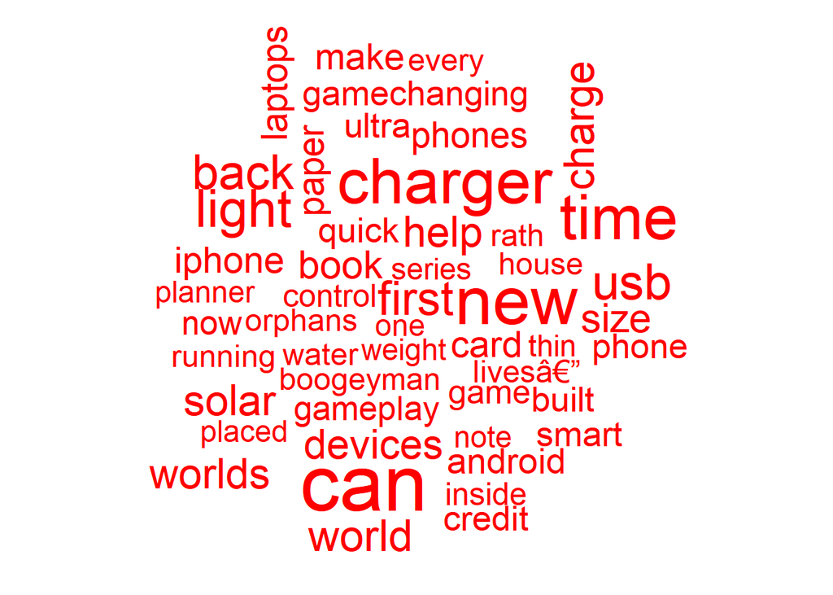

```r
wordcloud(top50_word_s$term, top50_word_s$count,
         max.words = 100, colors = "red")
```

```r
top200_word_f <- df_str_bot %>%
  group_by(term) %>%  dplyr::summarise(count = n()) %>% arrange(desc(count)) %>% top_n(200)
top200_word_s <- df_str_top %>%
  group_by(term) %>%  dplyr::summarise(count = n()) %>% arrange(desc(count)) %>% top_n(200)
```

2. Success in words Provide a pyramid plot to show how the words between successful and unsuccessful projects differ in frequency. A selection of 10 - 20 top words is sufficient here.

```r
word_com <- inner_join(top200_word_s, top200_word_f, by = c ("term"= "term") )
word_com <- word_com %>% mutate(count = count.x+count.y) %>% arrange(desc(count))%>% top_n(10)
```

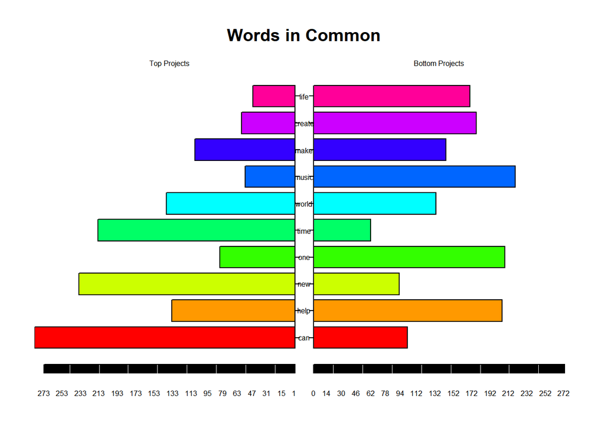

```
## 283 283
```

```r
p <- pyramid.plot(word_com$count.x, word_com$count.y,
                  labels = word_com$term,
             gap = 10,
             top.labels = c("Top Projects", " ", "Bottom Projects"),
             main = "Words in Common",
             laxlab = NULL,
             raxlab = NULL,
             unit = NULL,
             labelcex=0.5)
```

3. Simplicity as a virtue These blurbs are short in length (max. 150 characters) but let’s see whether brevity and simplicity still matters. Calculate a readability measure (Flesh Reading Ease, Flesh Kincaid or any other comparable measure) for the texts. Visualize the relationship between the readability measure and one of the measures of success. Briefly comment on your finding.

There is no obvious relationship between Mean Sentence Length and backer number.

```r
require(quanteda)

corpus_tb <- corpus(d_tb$blurb)

read <- textstat_readability(corpus_tb, measure=c('Flesch','Flesch.Kincaid',        'meanSentenceLength','meanWordSyllables'))

read <- as.data.frame(read)
```

```r
read_2 <- cbind(read,d_tb$backers_count.x)
```

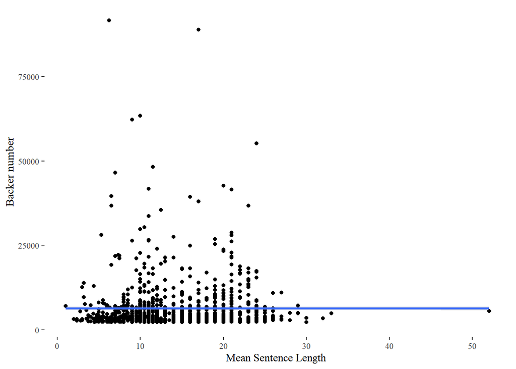

```r
ggplot(data=read_2, aes(x=meanSentenceLength, y=`d_tb$backers_count.x`))  + geom_point()  + geom_smooth()+ theme_tufte() +
  xlab("Mean Sentence Length ") + ylab("Backer number")
```

3. Sentiment Now, let’s check whether the use of positive / negative words or specific emotions helps a project to be successful.
1. Stay positive Calculate the tone of each text based on the positive and negative words that are being used. You can rely on the Hu & Liu dictionary provided in lecture or use the Bing dictionary contained in the tidytext package (tidytext::sentiments). Visualize the relationship between tone of the document and success. Briefly comment.

```r
pos <- get_sentiments("bing") %>%   filter(sentiment == "positive")
neg <- get_sentiments("bing") %>%   filter(sentiment == "negative")
pos <- pos$word
neg <- neg$word
```

```r
myDict <- dictionary(list(pos = pos,
  neg = neg  ))
# We can use the dictionary when making the dfm:
sen <- dfm(str_tb, dictionary = myDict)
sen <- as.data.frame(sen)
sen <- sen %>% mutate(tone = (pos-neg)*500) %>% mutate(tone = coalesce(tone, 0))
head(sen)
```

```
##   doc_id pos neg tone
## 1  text1   0   0    0
## 2  text2   0   0    0
## 3  text3   1   1    0
## 4  text4   2   0 1000
## 5  text5   2   0 1000
## 6  text6   3   0 1500
```

```r
sen2 <- cbind(d_tb$backers_count.x,sen$tone)
sen2 <- as.data.frame(sen2)
glimpse(sen2)
```

```
## Rows: 2,000
## Columns: 2
## $ V1 <dbl> 4976, 3271, 2803, 7523, 3696, 23331, 11124, 3041, 3461, 2310, 39...
## $ V2 <dbl> 0, 0, 0, 1000, 1000, 1500, 0, 0, 0, 1000, 1000, 0, 0, -1000, 0, ...
```

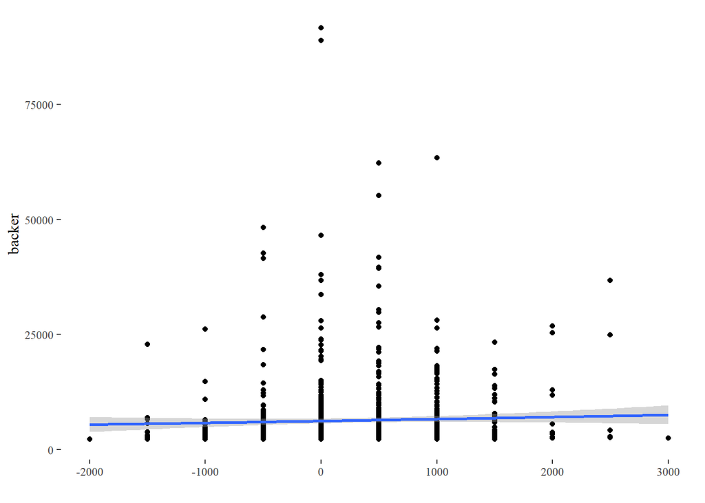

```r
ggplot(sen2,
  aes(x=V2, y=V1)) + geom_point() +
  ylab("backer") + xlab("") + theme_tufte() +
  geom_smooth()
```

2. Positive vs negative Segregate all 2,000 blurbs into positive and negative texts based on their polarity score calculated in step (a). Now, collapse the positive and negative texts into two larger documents. Create a document-term-matrix based on this collapsed set of two documents. Generate a comparison cloud showing the most-frequent positive and negative words.

```r
sen2 <- rename(sen2, c("V1" = "backer" ,"V2" = "tone"))
sen3 <- cbind(sen2,as.data.frame(str_tb))
sen_pos <- sen3 %>% filter(tone>0)
sen_neg <- sen3 %>% filter(tone<0)
glimpse(sen_neg)
```

```
## Rows: 294
## Columns: 3
## $ backer <dbl> 4562, 22840, 6650, 3609, 4068, 3998, 3116, 4962, 7158, 4351,...
## $ tone   <dbl> -1000, -1500, -1500, -500, -500, -500, -500, -500, -500, -10...
## $ V1     <chr> "crowds can slow wifi crawl portal stream ultrahd videos wit...
```

```r
glimpse(sen_pos)
```

```
## Rows: 933
## Columns: 3
## $ backer <dbl> 7523, 3696, 23331, 2310, 3925, 7876, 3715, 7857, 3227, 12377...
## $ tone   <dbl> 1000, 1000, 1500, 1000, 1000, 1500, 500, 1000, 500, 500, 100...
## $ V1     <chr> "turn smart phone tablet pc sophisticated diagnostic scan to...
```

```r
negtext <-paste(sen_neg$V1, collapse = '')
postext <-paste(sen_pos$V1, collapse = '')

t1<- c(negtext,postext)

text <- data.frame(t1)

text <- Corpus(VectorSource(text$t1))

tdm_text <- TermDocumentMatrix(text) %>%
  as.matrix()

colnames(tdm_text) <- c("negative","positive")
```

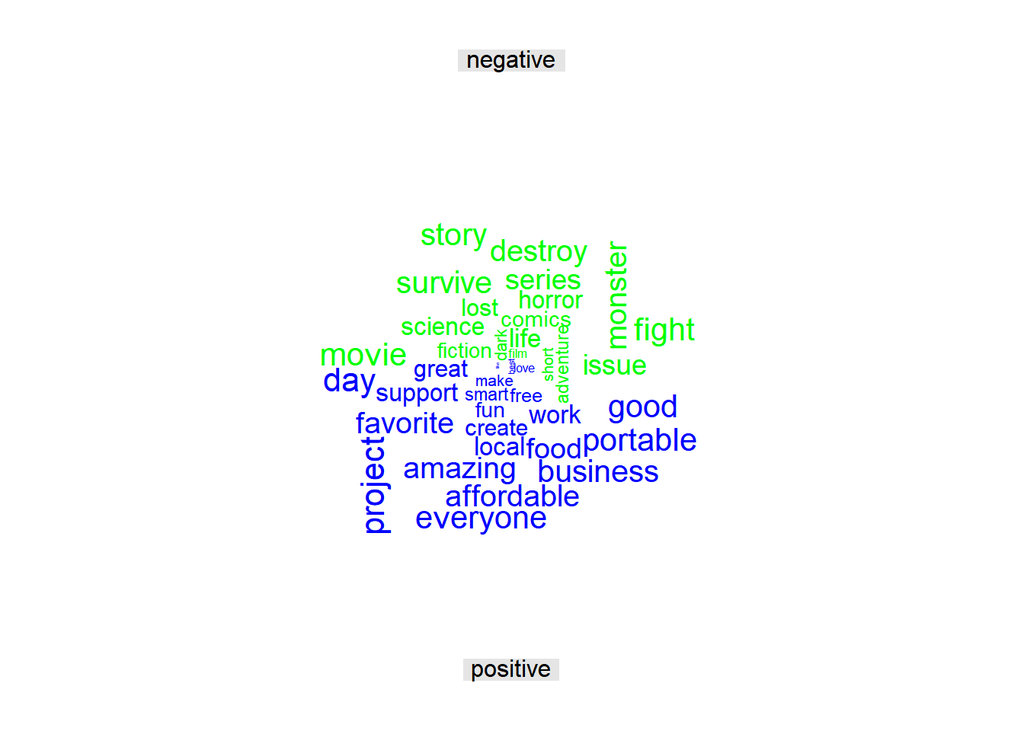

```r
comparison.cloud(tdm_text, colors = c("green", "blue"),
                 scale=c(0.2,2), title.size= 1,
                 max.words = 40)
```

3. Get in their mind Now, use the NRC Word-Emotion Association Lexicon in the tidytext package to identify a larger set of emotions (anger, anticipation, disgust, fear, joy, sadness, surprise, trust). Again, visualize the relationship between the use of words from these categories and success. What is your finding?

No obvious relationship between these categories emotions and success (meansured by backer number)

```r
nrc_anger <- get_sentiments("nrc") %>% filter(sentiment == "anger")
dict_anger  <- dictionary(list(anger = nrc_anger  ))
sen_anger <- dfm(str_tb, dictionary = dict_anger)
sen_anger <- as.data.frame(sen_anger)
sen_anger <- cbind(d_tb$backers_count.x,sen_anger)
sen_anger <- as.data.frame(sen_anger)
sen_anger <- rename(sen_anger, c( "d_tb$backers_count.x"=  "backer" ))

glimpse(sen_anger)
```

```
## Rows: 2,000
## Columns: 4
## $ backer          <int> 4976, 3271, 2803, 7523, 3696, 23331, 11124, 3041, 3...
## $ doc_id          <chr> "text1", "text2", "text3", "text4", "text5", "text6...
## $ anger.word      <dbl> 0, 0, 1, 0, 0, 0, 0, 0, 0, 0, 1, 0, 0, 1, 1, 1, 0, ...
## $ anger.sentiment <dbl> 0, 0, 0, 0, 0, 0, 0, 0, 0, 0, 0, 0, 0, 0, 0, 0, 0, ...
```

```r
sen_anger <- rename(sen_anger, c( "anger.word"=  "anger" ))
sen_anger2 <- sen_anger %>% drop_na() %>% group_by(anger) %>% summarise_each(funs(mean), backer)
```

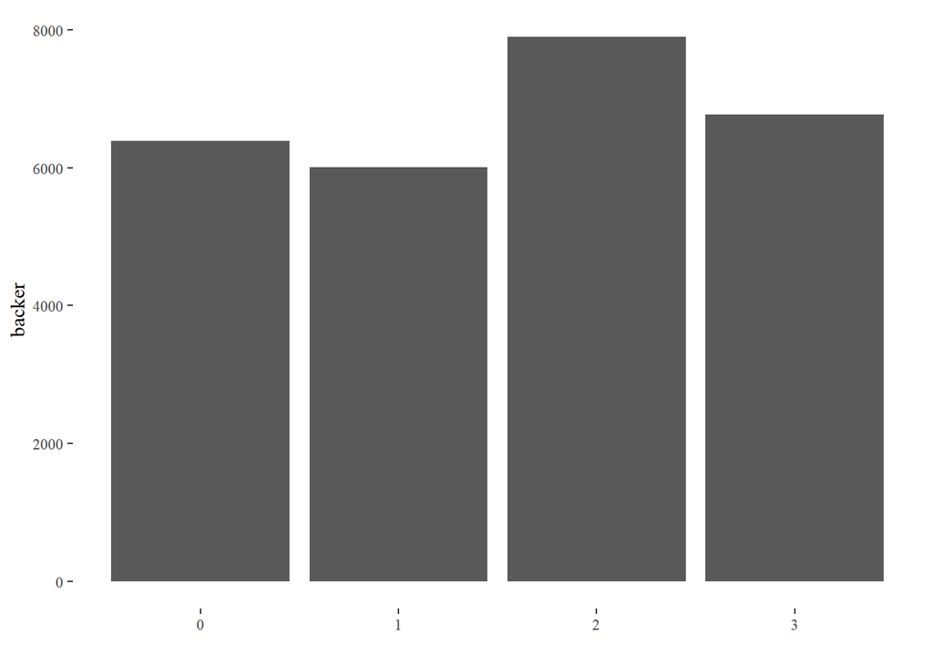

```r
ggplot(sen_anger2, aes(x = anger, y=backer)) + geom_bar(stat ="identity")+
  ylab("backer") + xlab("") + theme_tufte()
```

```r
nrc_anticipation <- get_sentiments("nrc") %>% filter(sentiment == "anticipation")
dict_anticipation  <- dictionary(list(anticipation = nrc_anticipation  ))
sen_anticipation <- dfm(str_tb, dictionary = dict_anticipation)
sen_anticipation <- as.data.frame(sen_anticipation)
```

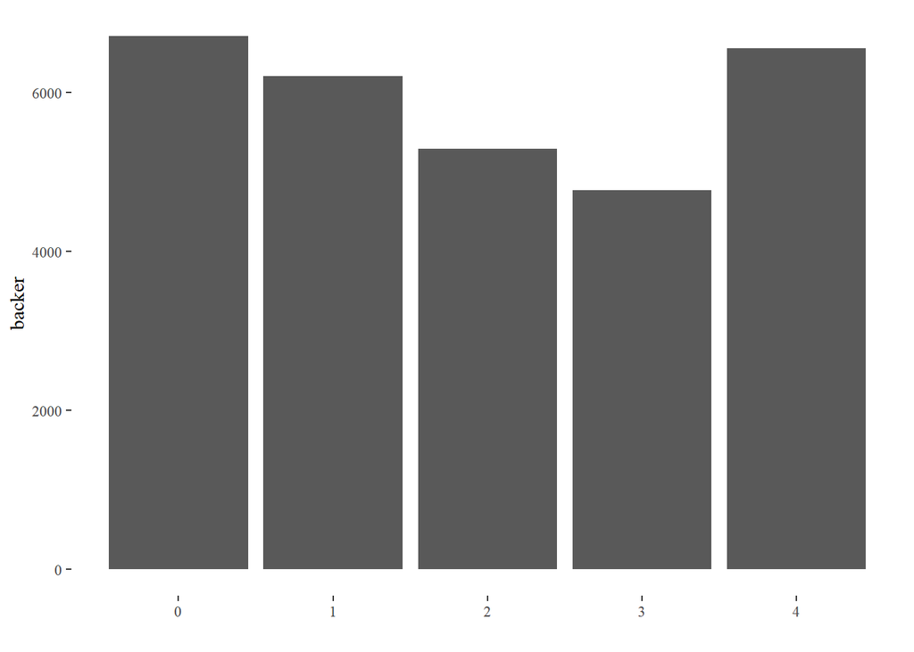

```r
sen_anticipation <- cbind(d_tb$backers_count.x,sen_anticipation)
sen_anticipation <- as.data.frame(sen_anticipation)

sen_anticipation <- rename(sen_anticipation, c(   "d_tb$backers_count.x" = "backer"))
sen_anticipation <- rename(sen_anticipation, c( "anticipation.word"=  "anticipation" ))
sen_anticipation2 <- sen_anticipation %>% drop_na() %>% group_by(anticipation) %>% summarise_each(funs(mean), backer)
ggplot(sen_anticipation2, aes(x = anticipation, y=backer)) + geom_bar(stat ="identity")+
  ylab("backer") + xlab("") + theme_tufte()
```

```r
nrc_disgust <- get_sentiments("nrc") %>% filter(sentiment == "disgust")
dict_disgust  <- dictionary(list(disgust = nrc_disgust  ))
sen_disgust <- dfm(str_tb, dictionary = dict_disgust)
sen_disgust <- as.data.frame(sen_disgust)
```

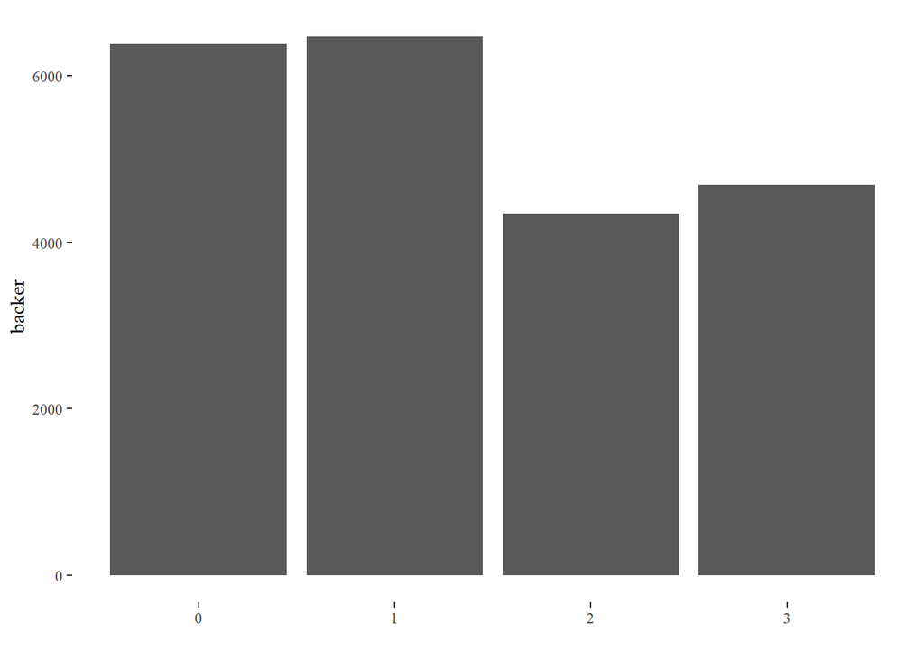

```r
sen_disgust <- cbind(d_tb$backers_count.x,sen_disgust)
sen_disgust <- as.data.frame(sen_disgust)

sen_disgust <- rename(sen_disgust, c(  "d_tb$backers_count.x" = "backer"))
sen_disgust <- rename(sen_disgust, c( "disgust.word"=  "disgust" ))
sen_disgust2 <- sen_disgust %>% drop_na() %>% group_by(disgust) %>% summarise_each(funs(mean), backer)
ggplot(sen_disgust2, aes(x = disgust, y=backer)) + geom_bar(stat ="identity")+
  ylab("backer") + xlab("") + theme_tufte()
```